# TP de calcul formel (GIE1 Gr32)

## Durée : 3 h

Vous répondrez en donnant tous les résultats exacts ou tout au moins corrects à $10^{-4}$ près.

# Préliminaires

Charger toutes les fonctions de la librairie de calcul symbolique et exécuter la fonction permettant d'afficher les résultats à venir sous une forme mathématique.

# Questions

1- Affecter à $x_0$ et $x_1$ les valeurs envoyées par mail (avec une seule instruction).

Résoudre l'équation $-x_0*x^2+2x+x_1=1$. Indiquer la plus petite des solutions (à $10^{-4}$ près).

2- On considère la matrice définie par $ m = \left( \begin{array}{cc} x_1 & 1 & x_0 & 1 \\ x_0 & x_0 & x_0 & x_0 \\ 0 & 0 & 0 & 0 \\ 1 & 2 & 3 & 4 \end{array} \right) $.

Indiquer la valeur du coefficent en bas à droite de la matrice $m^4$ pour vos valeurs de $x_0$ et $x_1$.

3- Résoudre l'équation différentielle $y''(t)- x_0 y'(t) + x_1 y(t) = 3t$ avec les conditions aux limites y(0)=1 et y'(0)=3. Puis indiquer la valeur (approchée à $10^{-4}$ près) de la solution obtenue en $t=1/2$.

4- On considère la matrice $ m = \left( \begin{array}{cc} 1 & x0 \\ 3x0 & x1 \\ \end{array} \right) $.

Indiquer l'ordonnée du vecteur propre de $m$ d'abscisse 1 et associé à la plus petite des valeurs propres de $m$ (à $10^{-4}$ près).

5- Soit $f$ la fonction qui à tout réel $x$ associe le plus grand entier $n$ tel que $\sum_{i=1}^{n}\frac{x0}{i} \le x$.

Indiquer la valeur de $max(f(x_0+x_1),f(2x_0+x_1))$.

6- Ecrire et éxécuter les instructions permettant de visualiser le signal en créneaux de fréquence $x_0$ Hz et oscillant entre 0 V et $x_1$ V.

L'exemple ci-dessous correspond au cas d'une fréquence 50 Hz et d'une amplitude 70 V :

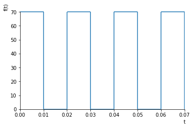

Superposer à cette courbe la représentation graphique de la série de Fourier de ce signal en négligeant les harmoniques d'ordres $n \gt 4$.

Représenter le spectre en amplitude de ce signal pour les fréquences de $-6 x_0$ Hz jusqu'à $6 x_0$ Hz.

6-1- Indiquer l'amplitude en Volt du 3ème harmonique (pour $n=3$).

6-2- Indiquer le déphasage (en rad, à $10^{-4}$ près) du 3ème harmonique.

6-3- Indiquer la valeur en Volt du 1er harmonique au temps $t = \frac{1}{3*x_0}$

6-4 Indiquer la fréquence (en Hz, à $10^{-4}$ près) du 5ème harmonique